# viz- and vocab-first intro to stats curricula: leveraging ggplot2 extension

## gg x ISI x EAPOST

## bit.ly/gg-eapost

#### Dr. Evangeline Reynolds | 2026-11-20 | EAPOST webinar, Image credit: Silas Baisch, Upsplash

[figure not shown]

Dr. Jennifer McNally, Inclusive Statistics this summer...

Now... Adjuncting 🤞 at DU...

A little about me and teaching, viz, and programming background:

-   2018-2020 - University of Denver
-   2020-2023 - West Point
-   2023 - present back in Denver...

# DU 2018-2020: quantitative methodology

-   2018-2020 - University of Denver, Visiting Teaching Assistant Professor

[figure not shown]

## Spring 2020 'Can you teach a data viz graduate level class?' George F. DeMartino, Ilene Grabel

# 'A ggplot2 grammar guide':

[figure not shown]

# West Point Fall 2020-2023

-   2020-2023 - Institutional Analytics and Math Intro to Statistics and Probability Instructor, Institutional Research Data Scientist...

> The text differs from traditional texts in both content and pedagogy. Statistical inference is introduced using simulation-based methods in Chapter 1. This allows students to intuitively understand the process of inference from the very beginning of their course.

# A 'Cathedral of Statistics'

[figure not shown]

> 'Statistics Curricula should reveal the beautiful cathedral of Statistics.' paraphrase ... George Cobb (paraphrase)

# GAISE grounded

EAPOST:

'We are aiming for substantial impact on instruction in the art and practice of statistical thinking, aligned with the American Statistical Association's Guidelines for Assessment and Instruction in Statistics Education (GAISE) and current research on teaching and learning in statistics. '

<https://sites.google.com/view/eaapost/project-overview>

[figure not shown]

> 'Some instructors may train students in using a specific software package, but mastery of advanced programming skills should not be allowed to crowd out data analysis skills or statistical thinking.'

[figure not shown]

# But, missing gg code and grammar of graphics 😢

*"**I just don't see how a world that makes such wonderful things could be bad."***

[figure not shown]

Can we have it all? Vis + Code + 'not crowd out statistical thinking'...

## Code + viz? \| grammar + viz? \| language + viz?

Because writing things down, feels very grounding. Having verbal expression and visual expression side by side, coordinated feels like a superpower.

[figure not shown]

And ggplot2 has extraordinary 'write down your narrative' capabilities

## BBC, Hans Rosling 200 years in 4 minutes

[figure not shown]

## BBC, Hans Rosling 200 years in 4 minutes

[figure not shown]

## BBC, Hans Rosling 200 years in 4 minutes

[figure not shown]

## BBC, Hans Rosling 200 years in 4 minutes

[figure not shown]

## BBC, Hans Rosling 200 years in 4 minutes

[figure not shown]

## BBC, Hans Rosling 200 years in 4 minutes

[figure not shown]

```r
gapminder::gapminder
```

```
# A tibble: 1,704 × 6
   country     continent  year lifeExp      pop gdpPercap
   <fct>       <fct>     <int>   <dbl>    <int>     <dbl>
 1 Afghanistan Asia       1952    28.8  8425333      779.
 2 Afghanistan Asia       1957    30.3  9240934      821.
 3 Afghanistan Asia       1962    32.0 10267083      853.
 4 Afghanistan Asia       1967    34.0 11537966      836.
 5 Afghanistan Asia       1972    36.1 13079460      740.
 6 Afghanistan Asia       1977    38.4 14880372      786.
 7 Afghanistan Asia       1982    39.9 12881816      978.
 8 Afghanistan Asia       1987    40.8 13867957      852.
 9 Afghanistan Asia       1992    41.7 16317921      649.
10 Afghanistan Asia       1997    41.8 22227415      635.
# ℹ 1,694 more rows
```

```r
gapminder::gapminder |>
* filter(year == 2002)
```

```
# A tibble: 142 × 6
   country     continent  year lifeExp       pop gdpPercap
   <fct>       <fct>     <int>   <dbl>     <int>     <dbl>
 1 Afghanistan Asia       2002    42.1  25268405      727.
 2 Albania     Europe     2002    75.7   3508512     4604.
 3 Algeria     Africa     2002    71.0  31287142     5288.
 4 Angola      Africa     2002    41.0  10866106     2773.
 5 Argentina   Americas   2002    74.3  38331121     8798.
 6 Australia   Oceania    2002    80.4  19546792    30688.
 7 Austria     Europe     2002    79.0   8148312    32418.
 8 Bahrain     Asia       2002    74.8    656397    23404.
 9 Bangladesh  Asia       2002    62.0 135656790     1136.
10 Belgium     Europe     2002    78.3  10311970    30486.
# ℹ 132 more rows
```

```r
gapminder::gapminder |>
  filter(year == 2002) |>
* ggplot()
```

[figure not shown]

```r
gapminder::gapminder |>
  filter(year == 2002) |>
  ggplot() +
* ggchalkboard:::theme_rosling()
```

[figure not shown]

```r
gapminder::gapminder |>
  filter(year == 2002) |>
  ggplot() +
  ggchalkboard:::theme_rosling() +
* aes(y = lifeExp)
```

[figure not shown]

```r
gapminder::gapminder |>
  filter(year == 2002) |>
  ggplot() +
  ggchalkboard:::theme_rosling() +
  aes(y = lifeExp) +
* aes(x = gdpPercap)
```

[figure not shown]

```r
gapminder::gapminder |>
  filter(year == 2002) |>
  ggplot() +
  ggchalkboard:::theme_rosling() +
  aes(y = lifeExp) +
  aes(x = gdpPercap) +
* geom_point()
```

[figure not shown]

```r
gapminder::gapminder |>
  filter(year == 2002) |>
  ggplot() +
  ggchalkboard:::theme_rosling() +
  aes(y = lifeExp) +
  aes(x = gdpPercap) +
  geom_point() +
* aes(color = continent)
```

[figure not shown]

```r
gapminder::gapminder |>
  filter(year == 2002) |>
  ggplot() +
  ggchalkboard:::theme_rosling() +
  aes(y = lifeExp) +
  aes(x = gdpPercap) +
  geom_point() +
  aes(color = continent) +
* aes(size = pop)
```

[figure not shown]

# coordinated visual and verbal -> limbic?

```r
library(ggregions)
```

# coordinated visual and verbal -> limbic?

```r
library(ggregions)
set_regions(brain_lobes_ref)
```

# coordinated visual and verbal -> limbic?

```r
library(ggregions)
set_regions(brain_lobes_ref)

ggplot()
```

[figure not shown]

# coordinated visual and verbal -> limbic?

```r
library(ggregions)
set_regions(brain_lobes_ref)

ggplot() +
* stamp_region()
```

[figure not shown]

# coordinated visual and verbal -> limbic?

```r
library(ggregions)
set_regions(brain_lobes_ref)

ggplot() +
  stamp_region() +
* stamp_region(keep = "Occipital",
*              fill = "cornflowerblue")
```

[figure not shown]

# coordinated visual and verbal -> limbic?

```r
library(ggregions)
set_regions(brain_lobes_ref)

ggplot() +
  stamp_region() +
  stamp_region(keep = "Occipital",
               fill = "cornflowerblue") +
* stamp_region(keep = "Temporal",
*              fill = "coral3")
```

[figure not shown]

# coordinated visual and verbal -> limbic?

```r
library(ggregions)
set_regions(brain_lobes_ref)

ggplot() +
  stamp_region() +
  stamp_region(keep = "Occipital",
               fill = "cornflowerblue") +
  stamp_region(keep = "Temporal",
               fill = "coral3") +
* stamp_region(keep = "Limbic",
*              fill = "goldenrod")
```

[figure not shown]

## ggplot2 lets us *transcribe* statistical narratives,

## record logic of visually conveyed ideas...

## our trains of thought

# 🤯🤯🤯🤯🤯🤯

### Should we reorganize our conversations into a haiku?

> 'Graphical Poems?' Hadley Wickham 2010 "A layered grammar of graphics'

```r
gapminder::gapminder |>
  filter(year == 2002) |>
* ggplot(mapping = aes(y = lifeExp,
*            x = gdpPercap,
*            color = continent,
*            size = pop)) +
  geom_point() +
  ggchalkboard:::theme_rosling()
```

[figure not shown]

'A question that I'd wanted to ask ... was about this syntax...'

```r
ggplot(cars) +
*  aes(x = dist) +
   geom_histogram()
```

[figure not shown]

> 'Does it still make you cringe?  Or don't care anymore? To me, ggplot2's overlooked superpower (but I find myself still self conscious about using it). '

> 'I still don't like it :)' - Hadley Wickham, creator of ggplot2, July 2026

ggplot2 excels in:

# Temporal

# Fidelity

## process preserving...

## conversation recording

## idea tracing

## There's magic is in the conversation... 🗣️🗣️

But... ISI - a *cathedral of statistics*...

*base* ggplot2, while conversational, is not enough...

Linear model w/ base ggplot

```r
ggplot(mtcars)
```

[figure not shown]

Linear model w/ base ggplot

```r
ggplot(mtcars) +
* aes(wt, mpg)
```

[figure not shown]

Linear model w/ base ggplot

```r
ggplot(mtcars) +
  aes(wt, mpg) +
* geom_point()
```

[figure not shown]

Linear model w/ base ggplot

```r
ggplot(mtcars) +
  aes(wt, mpg) +
  geom_point() +
* geom_smooth(method = lm)
```

[figure not shown]

Linear model w/ base ggplot

```r
ggplot(mtcars) +
  aes(wt, mpg) +
  geom_point() +
  geom_smooth(method = lm) +
* stat_smooth(method = lm,
*             geom = "point",
*             xseq = mtcars$wt,
*             color = "blue")
```

[figure not shown]

Linear model w/ base ggplot

```r
ggplot(mtcars) +
  aes(wt, mpg) +
  geom_point() +
  geom_smooth(method = lm) +
  stat_smooth(method = lm,
              geom = "point",
              xseq = mtcars$wt,
              color = "blue") +
* geom_smooth(method = lm,
*             formula = y ~ 1)
```

[figure not shown]

Not GAISE compliant ... 'software should not crowd out statistical thinking'...

And *not* as low of a level that you might need in a statistics class room....

[figure not shown]

Linguist S.I. Hayakawa in 1939: "Language in Action." New York: Harcourt, Brace.

Cobb: 'For most students, their noses stay too close to the canvas, they only see *disconnected* details. '

# No.

# Logical.

# Leaps.

# No.

# Missing.

# Rungs.

[figure not shown]

> 'Extending `ggplot2` [using ggproto extension points] is not for the faint-hearted.'

- 2022-Present - Community Organizer, co-founder: ggplot2 extenders meetup

[figure not shown]

Education... Easy geom recipes...

# Finally, main topic... gg extension X ISI X EAPOST?

-   ggprop.test <https://github.com/EvaMaeRey/ggprop.test>
-   ggt.test <https://evamaerey.github.io/ggt.test/>
-   ggxmeans <https://github.com/EvaMaeRey/ggxmean>

<https://evamaerey.github.io/mytidytuesday/2026-05-04-ggttest-ggram/intro-stats-narrative.html>

```r
library(tidyverse)
```

```r
library(tidyverse)
library(ggprop.test)
```

```r
library(tidyverse)
library(ggprop.test)

dolphin_data
```

```
# A tibble: 16 × 1
   observed
   <fct>
 1 Correct (1)
 2 Correct (1)
 3 Correct (1)
 4 Correct (1)
 5 Correct (1)
 6 Not Correct (0)
 7 Correct (1)
 8 Correct (1)
 9 Correct (1)
10 Correct (1)
11 Correct (1)
12 Correct (1)
13 Correct (1)
14 Correct (1)
15 Correct (1)
16 Correct (1)
```

```r
library(tidyverse)
library(ggprop.test)

dolphin_data |>
* ggplot()
```

[figure not shown]

```r
library(tidyverse)
library(ggprop.test)

dolphin_data |>
  ggplot() +
* labs(title = "Do Doris and Buzz Communicate 🐬🐬🐟🪣?")
```

[figure not shown]

```r
library(tidyverse)
library(ggprop.test)

dolphin_data |>
  ggplot() +
  labs(title = "Do Doris and Buzz Communicate 🐬🐬🐟🪣?") +
* aes(x = observed)
```

[figure not shown]

```r
library(tidyverse)
library(ggprop.test)

dolphin_data |>
  ggplot() +
  labs(title = "Do Doris and Buzz Communicate 🐬🐬🐟🪣?") +
  aes(x = observed) +
* geom_stack()
```

[figure not shown]

```r
library(tidyverse)
library(ggprop.test)

dolphin_data |>
  ggplot() +
  labs(title = "Do Doris and Buzz Communicate 🐬🐬🐟🪣?") +
  aes(x = observed) +
  geom_stack() +
* geom_stack_label()
```

[figure not shown]

```r
library(tidyverse)
library(ggprop.test)

dolphin_data |>
  ggplot() +
  labs(title = "Do Doris and Buzz Communicate 🐬🐬🐟🪣?") +
  aes(x = observed) +
  geom_stack() +
  geom_stack_label() +
* geom_support()
```

[figure not shown]

```r
library(tidyverse)
library(ggprop.test)

dolphin_data |>
  ggplot() +
  labs(title = "Do Doris and Buzz Communicate 🐬🐬🐟🪣?") +
  aes(x = observed) +
  geom_stack() +
  geom_stack_label() +
  geom_support() +
* geom_prop()
```

[figure not shown]

```r
library(tidyverse)
library(ggprop.test)

dolphin_data |>
  ggplot() +
  labs(title = "Do Doris and Buzz Communicate 🐬🐬🐟🪣?") +
  aes(x = observed) +
  geom_stack() +
  geom_stack_label() +
  geom_support() +
  geom_prop() +
* geom_prop_label()
```

[figure not shown]

```r
library(tidyverse)
library(ggprop.test)

dolphin_data |>
  ggplot() +
  labs(title = "Do Doris and Buzz Communicate 🐬🐬🐟🪣?") +
  aes(x = observed) +
  geom_stack() +
  geom_stack_label() +
  geom_support() +
  geom_prop() +
  geom_prop_label() +
* stamp_prop(.5)
```

[figure not shown]

```r
library(tidyverse)
library(ggprop.test)

dolphin_data |>
  ggplot() +
  labs(title = "Do Doris and Buzz Communicate 🐬🐬🐟🪣?") +
  aes(x = observed) +
  geom_stack() +
  geom_stack_label() +
  geom_support() +
  geom_prop() +
  geom_prop_label() +
  stamp_prop(.5) +
* stamp_prop_label(.5)
```

[figure not shown]

```r
library(tidyverse)
library(ggprop.test)

dolphin_data |>
  ggplot() +
  labs(title = "Do Doris and Buzz Communicate 🐬🐬🐟🪣?") +
  aes(x = observed) +
  geom_stack() +
  geom_stack_label() +
  geom_support() +
  geom_prop() +
  geom_prop_label() +
  stamp_prop(.5) +
  stamp_prop_label(.5) +
* geom_binomial_null(.5)
```

[figure not shown]

```r
donor_data
```

```
# A tibble: 161 × 1
   decision
   <fct>
 1 donor (1)
 2 donor (1)
 3 not (0)
 4 donor (1)
 5 not (0)
 6 not (0)
 7 not (0)
 8 not (0)
 9 not (0)
10 donor (1)
# ℹ 151 more rows
```

```r
donor_data |>
* ggplot()
```

[figure not shown]

```r
donor_data |>
  ggplot() +
* labs(title = "Organ donation🫀🫁responses like coin flips?")
```

[figure not shown]

```r
donor_data |>
  ggplot() +
  labs(title = "Organ donation🫀🫁responses like coin flips?") +
* aes(x = decision)
```

[figure not shown]

```r
donor_data |>
  ggplot() +
  labs(title = "Organ donation🫀🫁responses like coin flips?") +
  aes(x = decision) +
* geom_stack()
```

[figure not shown]

```r
donor_data |>
  ggplot() +
  labs(title = "Organ donation🫀🫁responses like coin flips?") +
  aes(x = decision) +
  geom_stack() +
* geom_stack_label()
```

[figure not shown]

```r
donor_data |>
  ggplot() +
  labs(title = "Organ donation🫀🫁responses like coin flips?") +
  aes(x = decision) +
  geom_stack() +
  geom_stack_label() +
* geom_support()
```

[figure not shown]

```r
donor_data |>
  ggplot() +
  labs(title = "Organ donation🫀🫁responses like coin flips?") +
  aes(x = decision) +
  geom_stack() +
  geom_stack_label() +
  geom_support() +
* geom_prop()
```

[figure not shown]

```r
donor_data |>
  ggplot() +
  labs(title = "Organ donation🫀🫁responses like coin flips?") +
  aes(x = decision) +
  geom_stack() +
  geom_stack_label() +
  geom_support() +
  geom_prop() +
* geom_prop_label()
```

[figure not shown]

```r
donor_data |>
  ggplot() +
  labs(title = "Organ donation🫀🫁responses like coin flips?") +
  aes(x = decision) +
  geom_stack() +
  geom_stack_label() +
  geom_support() +
  geom_prop() +
  geom_prop_label() +
* stamp_prop(.5)
```

[figure not shown]

```r
donor_data |>
  ggplot() +
  labs(title = "Organ donation🫀🫁responses like coin flips?") +
  aes(x = decision) +
  geom_stack() +
  geom_stack_label() +
  geom_support() +
  geom_prop() +
  geom_prop_label() +
  stamp_prop(.5) +
* stamp_prop_label(.5)
```

[figure not shown]

```r
donor_data |>
  ggplot() +
  labs(title = "Organ donation🫀🫁responses like coin flips?") +
  aes(x = decision) +
  geom_stack() +
  geom_stack_label() +
  geom_support() +
  geom_prop() +
  geom_prop_label() +
  stamp_prop(.5) +
  stamp_prop_label(.5) +
* geom_binomial_null(.5)
```

[figure not shown]

```r
p <- dolphin_data |>
  ggplot() +
  labs(title = "Do Doris and Buzz Communicate 🐬🐬🐟🪣?") +
  aes(x = observed) +
  geom_stack() +
  geom_stack_label() +
  geom_support() +
  geom_prop() +
  geom_prop_label()
```

simulation based inference

```r
p
```

[figure not shown]

simulation based inference

```r
p +
* labs(title = "What's consistent with 16 coin flips? \n🪙🪙🪙🪙🪙🪙🪙🪙🪙🪙🪙🪙🪙🪙🪙🪙")
```

[figure not shown]

simulation based inference

```r
p +
  labs(title = "What's consistent with 16 coin flips? \n🪙🪙🪙🪙🪙🪙🪙🪙🪙🪙🪙🪙🪙🪙🪙🪙") +
* dolphin_data |> mutate(observed =
*                          to_synthetic(observed))
```

[figure not shown]

simulation based inference

```r
p +
  labs(title = "What's consistent with 16 coin flips? \n🪙🪙🪙🪙🪙🪙🪙🪙🪙🪙🪙🪙🪙🪙🪙🪙") +
  dolphin_data |> mutate(observed =
                           to_synthetic(observed)) +
* dolphin_data |> mutate(observed = to_synthetic(observed))
```

[figure not shown]

simulation based inference

```r
p +
  labs(title = "What's consistent with 16 coin flips? \n🪙🪙🪙🪙🪙🪙🪙🪙🪙🪙🪙🪙🪙🪙🪙🪙") +
  dolphin_data |> mutate(observed =
                           to_synthetic(observed)) +
  dolphin_data |> mutate(observed = to_synthetic(observed)) +
* dolphin_data |> mutate(observed = to_synthetic(observed))
```

[figure not shown]

simulation based inference

```r
p +
  labs(title = "What's consistent with 16 coin flips? \n🪙🪙🪙🪙🪙🪙🪙🪙🪙🪙🪙🪙🪙🪙🪙🪙") +
  dolphin_data |> mutate(observed =
                           to_synthetic(observed)) +
  dolphin_data |> mutate(observed = to_synthetic(observed)) +
  dolphin_data |> mutate(observed = to_synthetic(observed)) +
* dolphin_data |> mutate(observed = to_synthetic(observed))
```

[figure not shown]

simulation based inference

```r
p +
  labs(title = "What's consistent with 16 coin flips? \n🪙🪙🪙🪙🪙🪙🪙🪙🪙🪙🪙🪙🪙🪙🪙🪙") +
  dolphin_data |> mutate(observed =
                           to_synthetic(observed)) +
  dolphin_data |> mutate(observed = to_synthetic(observed)) +
  dolphin_data |> mutate(observed = to_synthetic(observed)) +
  dolphin_data |> mutate(observed = to_synthetic(observed)) +
* dolphin_data |> mutate(observed = to_synthetic(observed))
```

[figure not shown]

simulation based inference

```r
p +
  labs(title = "What's consistent with 16 coin flips? \n🪙🪙🪙🪙🪙🪙🪙🪙🪙🪙🪙🪙🪙🪙🪙🪙") +
  dolphin_data |> mutate(observed =
                           to_synthetic(observed)) +
  dolphin_data |> mutate(observed = to_synthetic(observed)) +
  dolphin_data |> mutate(observed = to_synthetic(observed)) +
  dolphin_data |> mutate(observed = to_synthetic(observed)) +
  dolphin_data |> mutate(observed = to_synthetic(observed)) +
* dolphin_data |> mutate(observed = to_synthetic(observed))
```

[figure not shown]

simulation based inference

```r
p +
  labs(title = "What's consistent with 16 coin flips? \n🪙🪙🪙🪙🪙🪙🪙🪙🪙🪙🪙🪙🪙🪙🪙🪙") +
  dolphin_data |> mutate(observed =
                           to_synthetic(observed)) +
  dolphin_data |> mutate(observed = to_synthetic(observed)) +
  dolphin_data |> mutate(observed = to_synthetic(observed)) +
  dolphin_data |> mutate(observed = to_synthetic(observed)) +
  dolphin_data |> mutate(observed = to_synthetic(observed)) +
  dolphin_data |> mutate(observed = to_synthetic(observed)) +
* dolphin_data |> mutate(observed = to_synthetic(observed))
```

[figure not shown]

simulation based inference

```r
p +
  labs(title = "What's consistent with 16 coin flips? \n🪙🪙🪙🪙🪙🪙🪙🪙🪙🪙🪙🪙🪙🪙🪙🪙") +
  dolphin_data |> mutate(observed =
                           to_synthetic(observed)) +
  dolphin_data |> mutate(observed = to_synthetic(observed)) +
  dolphin_data |> mutate(observed = to_synthetic(observed)) +
  dolphin_data |> mutate(observed = to_synthetic(observed)) +
  dolphin_data |> mutate(observed = to_synthetic(observed)) +
  dolphin_data |> mutate(observed = to_synthetic(observed)) +
  dolphin_data |> mutate(observed = to_synthetic(observed)) +
* dolphin_data |> mutate(observed = to_synthetic(observed))
```

[figure not shown]

simulation based inference

```r
p +
  labs(title = "What's consistent with 16 coin flips? \n🪙🪙🪙🪙🪙🪙🪙🪙🪙🪙🪙🪙🪙🪙🪙🪙") +
  dolphin_data |> mutate(observed =
                           to_synthetic(observed)) +
  dolphin_data |> mutate(observed = to_synthetic(observed)) +
  dolphin_data |> mutate(observed = to_synthetic(observed)) +
  dolphin_data |> mutate(observed = to_synthetic(observed)) +
  dolphin_data |> mutate(observed = to_synthetic(observed)) +
  dolphin_data |> mutate(observed = to_synthetic(observed)) +
  dolphin_data |> mutate(observed = to_synthetic(observed)) +
  dolphin_data |> mutate(observed = to_synthetic(observed)) +
* dolphin_data |> mutate(observed = to_synthetic(observed))
```

[figure not shown]

```r
library(ggprop.test)
tidy_dbinom(num_trials = 1, single_trial_prob = .5)
```

```
# A tibble: 2 × 4
  num_successes probability single_trial_prob num_trials
          <int>       <dbl>             <dbl>      <dbl>
1             0         0.5               0.5          1
2             1         0.5               0.5          1
```

```r
library(ggprop.test)
tidy_dbinom(num_trials = 2, single_trial_prob = .5)
```

```
# A tibble: 3 × 4
  num_successes probability single_trial_prob num_trials
          <int>       <dbl>             <dbl>      <dbl>
1             0        0.25               0.5          2
2             1        0.5                0.5          2
3             2        0.25               0.5          2
```

```r
library(ggprop.test)
tidy_dbinom(num_trials = 3, single_trial_prob = .5)
```

```
# A tibble: 4 × 4
  num_successes probability single_trial_prob num_trials
          <int>       <dbl>             <dbl>      <dbl>
1             0       0.125               0.5          3
2             1       0.375               0.5          3
3             2       0.375               0.5          3
4             3       0.125               0.5          3
```

```r
library(ggprop.test)
tidy_dbinom(num_trials = 4, single_trial_prob = .5)
```

```
# A tibble: 5 × 4
  num_successes probability single_trial_prob num_trials
          <int>       <dbl>             <dbl>      <dbl>
1             0      0.0625               0.5          4
2             1      0.25                 0.5          4
3             2      0.375                0.5          4
4             3      0.25                 0.5          4
5             4      0.0625               0.5          4
```

```r
library(ggprop.test)
tidy_dbinom(num_trials = 5, single_trial_prob = .5)
```

```
# A tibble: 6 × 4
  num_successes probability single_trial_prob num_trials
          <int>       <dbl>             <dbl>      <dbl>
1             0      0.0312               0.5          5
2             1      0.156                0.5          5
3             2      0.312                0.5          5
4             3      0.312                0.5          5
5             4      0.156                0.5          5
6             5      0.0312               0.5          5
```

```r
library(ggprop.test)
tidy_dbinom(num_trials = 6, single_trial_prob = .5)
```

```
# A tibble: 7 × 4
  num_successes probability single_trial_prob num_trials
          <int>       <dbl>             <dbl>      <dbl>
1             0      0.0156               0.5          6
2             1      0.0937               0.5          6
3             2      0.234                0.5          6
4             3      0.312                0.5          6
5             4      0.234                0.5          6
6             5      0.0937               0.5          6
7             6      0.0156               0.5          6
```

```r
library(ggprop.test)
tidy_dbinom(num_trials = 16, single_trial_prob = .5)
```

```
# A tibble: 17 × 4
   num_successes probability single_trial_prob num_trials
           <int>       <dbl>             <dbl>      <dbl>
 1             0   0.0000153               0.5         16
 2             1   0.000244                0.5         16
 3             2   0.00183                 0.5         16
 4             3   0.00854                 0.5         16
 5             4   0.0278                  0.5         16
 6             5   0.0667                  0.5         16
 7             6   0.122                   0.5         16
 8             7   0.175                   0.5         16
 9             8   0.196                   0.5         16
10             9   0.175                   0.5         16
11            10   0.122                   0.5         16
12            11   0.0667                  0.5         16
13            12   0.0278                  0.5         16
14            13   0.00854                 0.5         16
15            14   0.00183                 0.5         16
16            15   0.000244                0.5         16
17            16   0.0000153               0.5         16
```

## t test

```r
library(ggt.test)
```

## t test

```r
library(ggt.test)

data_grit_undergrad
```

```
# A tibble: 21 × 1
   score
   <dbl>
 1  3.18
 2  2.4
 3  3.2
 4  3.16
 5  3
 6  3.5
 7  3.6
 8  3.4
 9  3.42
10  2.3
# ℹ 11 more rows
```

## t test

```r
library(ggt.test)

data_grit_undergrad |>
* ggplot()
```

[figure not shown]

## t test

```r
library(ggt.test)

data_grit_undergrad |>
  ggplot() +
* labs(title = "As Gritty on average as West Point Cadets? 💪🪖🧗")
```

[figure not shown]

## t test

```r
library(ggt.test)

data_grit_undergrad |>
  ggplot() +
  labs(title = "As Gritty on average as West Point Cadets? 💪🪖🧗") +
* aes(score)
```

[figure not shown]

## t test

```r
library(ggt.test)

data_grit_undergrad |>
  ggplot() +
  labs(title = "As Gritty on average as West Point Cadets? 💪🪖🧗") +
  aes(score) +
* geom_rug()
```

[figure not shown]

## t test

```r
library(ggt.test)

data_grit_undergrad |>
  ggplot() +
  labs(title = "As Gritty on average as West Point Cadets? 💪🪖🧗") +
  aes(score) +
  geom_rug() +
* geom_stacks()
```

[figure not shown]

## t test

```r
library(ggt.test)

data_grit_undergrad |>
  ggplot() +
  labs(title = "As Gritty on average as West Point Cadets? 💪🪖🧗") +
  aes(score) +
  geom_rug() +
  geom_stacks() +
* geom_support()
```

[figure not shown]

## t test

```r
library(ggt.test)

data_grit_undergrad |>
  ggplot() +
  labs(title = "As Gritty on average as West Point Cadets? 💪🪖🧗") +
  aes(score) +
  geom_rug() +
  geom_stacks() +
  geom_support() +
* geom_mean()
```

[figure not shown]

## t test

```r
library(ggt.test)

data_grit_undergrad |>
  ggplot() +
  labs(title = "As Gritty on average as West Point Cadets? 💪🪖🧗") +
  aes(score) +
  geom_rug() +
  geom_stacks() +
  geom_support() +
  geom_mean() +
* geom_mean_label()
```

[figure not shown]

## t test

```r
library(ggt.test)

data_grit_undergrad |>
  ggplot() +
  labs(title = "As Gritty on average as West Point Cadets? 💪🪖🧗") +
  aes(score) +
  geom_rug() +
  geom_stacks() +
  geom_support() +
  geom_mean() +
  geom_mean_label() +
* stamp_mean(3.75)
```

[figure not shown]

## t test

```r
library(ggt.test)

data_grit_undergrad |>
  ggplot() +
  labs(title = "As Gritty on average as West Point Cadets? 💪🪖🧗") +
  aes(score) +
  geom_rug() +
  geom_stacks() +
  geom_support() +
  geom_mean() +
  geom_mean_label() +
  stamp_mean(3.75)  +
* geom_tdist_null(3.75)
```

[figure not shown]

## Difference in means

```r
data_haircuts
```

```
      sex price
1  Female    50
2    Male    20
3  Female    60
4    Male    75
5  Female   150
6    Male    23
7  Female    15
8  Female    90
9  Female    20
10 Female   110
11 Female     0
12 Female    40
13 Female    35
14   Male    20
15 Female    30
16 Female    50
17 Female    70
18 Female    50
19 Female    75
20 Female   150
21 Female    35
22 Female    45
23 Female    70
24 Female    50
25   Male    15
26 Female    20
27 Female   150
28 Female    45
29   Male     0
30   Male    22
31   Male    15
32 Female    65
33 Female   120
34 Female    45
35 Female    15
36 Female    25
37 Female     0
38   Male    20
39 Female    35
40 Female   120
41 Female    45
42 Female    30
43 Female    55
44 Female     0
45   Male     0
46 Female    15
47   Male     0
48   Male    14
49   Male    60
50 Female    20
```

## Difference in means

```r
data_haircuts |>
* ggplot()
```

[figure not shown]

## Difference in means

```r
data_haircuts |>
  ggplot() +
* labs(title = "Are haircut price averages different for men v. women")
```

[figure not shown]

## Difference in means

```r
data_haircuts |>
  ggplot() +
  labs(title = "Are haircut price averages different for men v. women") +
* aes(x = price)
```

[figure not shown]

## Difference in means

```r
data_haircuts |>
  ggplot() +
  labs(title = "Are haircut price averages different for men v. women") +
  aes(x = price) +
* geom_rug()
```

[figure not shown]

## Difference in means

```r
data_haircuts |>
  ggplot() +
  labs(title = "Are haircut price averages different for men v. women") +
  aes(x = price) +
  geom_rug() +
* geom_stacks()
```

[figure not shown]

## Difference in means

```r
data_haircuts |>
  ggplot() +
  labs(title = "Are haircut price averages different for men v. women") +
  aes(x = price) +
  geom_rug() +
  geom_stacks() +
* geom_mean()
```

[figure not shown]

## Difference in means

```r
data_haircuts |>
  ggplot() +
  labs(title = "Are haircut price averages different for men v. women") +
  aes(x = price) +
  geom_rug() +
  geom_stacks() +
  geom_mean() +
* geom_mean_label()
```

[figure not shown]

## Difference in means

```r
data_haircuts |>
  ggplot() +
  labs(title = "Are haircut price averages different for men v. women") +
  aes(x = price) +
  geom_rug() +
  geom_stacks() +
  geom_mean() +
  geom_mean_label() +
* facet_align(sex)
```

[figure not shown]

## Difference in means

```r
data_haircuts |>
  ggplot() +
  labs(title = "Are haircut price averages different for men v. women") +
  aes(x = price) +
  geom_rug() +
  geom_stacks() +
  geom_mean() +
  geom_mean_label() +
  facet_align(sex) +
* geom_mean_diff()
```

[figure not shown]

## Difference in means

```r
data_haircuts |>
  ggplot() +
  labs(title = "Are haircut price averages different for men v. women") +
  aes(x = price) +
  geom_rug() +
  geom_stacks() +
  geom_mean() +
  geom_mean_label() +
  facet_align(sex) +
  geom_mean_diff() +
* geom_mean_diff_label()
```

[figure not shown]

## linear model

```r
library(ggxmean)
```

## linear model

```r
library(ggxmean)

mtcars
```

```
                     mpg cyl  disp  hp drat    wt  qsec vs am gear carb
Mazda RX4           21.0   6 160.0 110 3.90 2.620 16.46  0  1    4    4
Mazda RX4 Wag       21.0   6 160.0 110 3.90 2.875 17.02  0  1    4    4
Datsun 710          22.8   4 108.0  93 3.85 2.320 18.61  1  1    4    1
Hornet 4 Drive      21.4   6 258.0 110 3.08 3.215 19.44  1  0    3    1
Hornet Sportabout   18.7   8 360.0 175 3.15 3.440 17.02  0  0    3    2
Valiant             18.1   6 225.0 105 2.76 3.460 20.22  1  0    3    1
Duster 360          14.3   8 360.0 245 3.21 3.570 15.84  0  0    3    4
Merc 240D           24.4   4 146.7  62 3.69 3.190 20.00  1  0    4    2
Merc 230            22.8   4 140.8  95 3.92 3.150 22.90  1  0    4    2
Merc 280            19.2   6 167.6 123 3.92 3.440 18.30  1  0    4    4
Merc 280C           17.8   6 167.6 123 3.92 3.440 18.90  1  0    4    4
Merc 450SE          16.4   8 275.8 180 3.07 4.070 17.40  0  0    3    3
Merc 450SL          17.3   8 275.8 180 3.07 3.730 17.60  0  0    3    3
Merc 450SLC         15.2   8 275.8 180 3.07 3.780 18.00  0  0    3    3
Cadillac Fleetwood  10.4   8 472.0 205 2.93 5.250 17.98  0  0    3    4
Lincoln Continental 10.4   8 460.0 215 3.00 5.424 17.82  0  0    3    4
Chrysler Imperial   14.7   8 440.0 230 3.23 5.345 17.42  0  0    3    4
Fiat 128            32.4   4  78.7  66 4.08 2.200 19.47  1  1    4    1
Honda Civic         30.4   4  75.7  52 4.93 1.615 18.52  1  1    4    2
Toyota Corolla      33.9   4  71.1  65 4.22 1.835 19.90  1  1    4    1
Toyota Corona       21.5   4 120.1  97 3.70 2.465 20.01  1  0    3    1
Dodge Challenger    15.5   8 318.0 150 2.76 3.520 16.87  0  0    3    2
AMC Javelin         15.2   8 304.0 150 3.15 3.435 17.30  0  0    3    2
Camaro Z28          13.3   8 350.0 245 3.73 3.840 15.41  0  0    3    4
Pontiac Firebird    19.2   8 400.0 175 3.08 3.845 17.05  0  0    3    2
Fiat X1-9           27.3   4  79.0  66 4.08 1.935 18.90  1  1    4    1
Porsche 914-2       26.0   4 120.3  91 4.43 2.140 16.70  0  1    5    2
Lotus Europa        30.4   4  95.1 113 3.77 1.513 16.90  1  1    5    2
Ford Pantera L      15.8   8 351.0 264 4.22 3.170 14.50  0  1    5    4
Ferrari Dino        19.7   6 145.0 175 3.62 2.770 15.50  0  1    5    6
Maserati Bora       15.0   8 301.0 335 3.54 3.570 14.60  0  1    5    8
Volvo 142E          21.4   4 121.0 109 4.11 2.780 18.60  1  1    4    2
```

## linear model

```r
library(ggxmean)

mtcars |>
* ggplot()
```

[figure not shown]

## linear model

```r
library(ggxmean)

mtcars |>
  ggplot() +
* labs(title = "Does weight predict milage? 🚙🚕🏎️")
```

[figure not shown]

## linear model

```r
library(ggxmean)

mtcars |>
  ggplot() +
  labs(title = "Does weight predict milage? 🚙🚕🏎️") +
* aes(x = wt)
```

[figure not shown]

## linear model

```r
library(ggxmean)

mtcars |>
  ggplot() +
  labs(title = "Does weight predict milage? 🚙🚕🏎️") +
  aes(x = wt) +
* geom_rug()
```

[figure not shown]

## linear model

```r
library(ggxmean)

mtcars |>
  ggplot() +
  labs(title = "Does weight predict milage? 🚙🚕🏎️") +
  aes(x = wt) +
  geom_rug() +
* aes(y = mpg)
```

[figure not shown]

## linear model

```r
library(ggxmean)

mtcars |>
  ggplot() +
  labs(title = "Does weight predict milage? 🚙🚕🏎️") +
  aes(x = wt) +
  geom_rug() +
  aes(y = mpg) +
* geom_point()
```

[figure not shown]

## linear model

```r
library(ggxmean)

mtcars |>
  ggplot() +
  labs(title = "Does weight predict milage? 🚙🚕🏎️") +
  aes(x = wt) +
  geom_rug() +
  aes(y = mpg) +
  geom_point() +
* geom_lm()
```

[figure not shown]

## linear model

```r
library(ggxmean)

mtcars |>
  ggplot() +
  labs(title = "Does weight predict milage? 🚙🚕🏎️") +
  aes(x = wt) +
  geom_rug() +
  aes(y = mpg) +
  geom_point() +
  geom_lm() +
* geom_lm_fitted()
```

[figure not shown]

## linear model

```r
library(ggxmean)

mtcars |>
  ggplot() +
  labs(title = "Does weight predict milage? 🚙🚕🏎️") +
  aes(x = wt) +
  geom_rug() +
  aes(y = mpg) +
  geom_point() +
  geom_lm() +
  geom_lm_fitted() +
* geom_lm_residuals()
```

[figure not shown]

## linear model

```r
library(ggxmean)

mtcars |>
  ggplot() +
  labs(title = "Does weight predict milage? 🚙🚕🏎️") +
  aes(x = wt) +
  geom_rug() +
  aes(y = mpg) +
  geom_point() +
  geom_lm() +
  geom_lm_fitted() +
  geom_lm_residuals() +
* geom_lm_conf_int()
```

[figure not shown]

## linear model

```r
library(ggxmean)

mtcars |>
  ggplot() +
  labs(title = "Does weight predict milage? 🚙🚕🏎️") +
  aes(x = wt) +
  geom_rug() +
  aes(y = mpg) +
  geom_point() +
  geom_lm() +
  geom_lm_fitted() +
  geom_lm_residuals() +
  geom_lm_conf_int() +
* geom_lm_formula()
```

[figure not shown]

## linear model

```r
library(ggxmean)

mtcars |>
  ggplot() +
  labs(title = "Does weight predict milage? 🚙🚕🏎️") +
  aes(x = wt) +
  geom_rug() +
  aes(y = mpg) +
  geom_point() +
  geom_lm() +
  geom_lm_fitted() +
  geom_lm_residuals() +
  geom_lm_conf_int() +
  geom_lm_formula() +
* geom_lm_intercept()
```

[figure not shown]

## linear model

```r
library(ggxmean)

mtcars |>
  ggplot() +
  labs(title = "Does weight predict milage? 🚙🚕🏎️") +
  aes(x = wt) +
  geom_rug() +
  aes(y = mpg) +
  geom_point() +
  geom_lm() +
  geom_lm_fitted() +
  geom_lm_residuals() +
  geom_lm_conf_int() +
  geom_lm_formula() +
  geom_lm_intercept() +
* geom_lm_intercept_label(hjust = 0)
```

[figure not shown]

https://github.com/arthurwelle/codehover/

| ggplot(dolphin_data) + |
| --- |
| labs(title = "Do Doris and Buzz Communicate 🐬🐬🐟🪣?") + |
| aes(x = observed) + |
| geom_stack() + |
| geom_stack_label() + |
| geom_support() + |
| geom_prop() + |
| geom_prop_label() + |
| stamp_prop(0.5) + |
| stamp_prop_label(0.5) + |
| geom_binomial_null(0.5) |

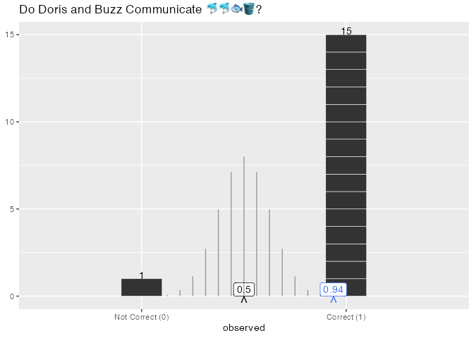

```r
{dolphin_data |>
  ggplot() +
  labs(title = "Do Doris and Buzz Communicate 🐬🐬🐟🪣?") +
  aes(x = observed) +
  geom_stack() +
  geom_stack_label() +
  geom_support() +
  geom_prop() +
  geom_prop_label() +
  stamp_prop(.5) +
  stamp_prop_label(.5) +
  geom_binomial_null(.5)} |>
  codehover::ch_hover()  #<<  in-script reveal - student - usable?
```